# feature_eng

```python
import pandas as pd
from statsmodels.tsa.seasonal import STL
import seaborn as sns
import matplotlib.pyplot as plt
import numpy as np
from statsmodels.graphics.tsaplots import plot_acf
from statsmodels.tsa.seasonal import seasonal_decompose
```

## 1. Wczytanie i przegląd danych

```python
df = pd.read_excel('PM_BDG.xlsx', names = ['Date', 'PM25'], skiprows = 5, index_col = 'Date')
df.index = pd.to_datetime(df.index)
```

```python
df
```

| Date | PM25 |
| --- | --- |
| 2022-01-01 | 4.934921 |
| 2022-01-02 | 10.341562 |
| 2022-01-03 | 5.007348 |
| 2022-01-04 | 9.688094 |
| 2022-01-05 | 5.914476 |
| ... | ... |
| 2022-12-27 | 2.195314 |
| 2022-12-28 | 4.317930 |
| 2022-12-29 | 5.061757 |
| 2022-12-30 | 5.950761 |
| 2022-12-31 | 8.273009 |

365 rows × 1 columns

```python
df.info()
```

```
<class 'pandas.core.frame.DataFrame'>
DatetimeIndex: 365 entries, 2022-01-01 to 2022-12-31
Data columns (total 1 columns):
 #   Column  Non-Null Count  Dtype
---  ------  --------------  -----
 0   PM25    365 non-null    float64
dtypes: float64(1)
memory usage: 5.7 KB
```

```python
df.describe()
```

|  | PM25 |
| --- | --- |
| count | 365.000000 |
| mean | 13.388558 |
| std | 9.827103 |
| min | 1.705395 |
| 25% | 6.712919 |
| 50% | 10.522706 |
| 75% | 16.328249 |
| max | 65.242437 |

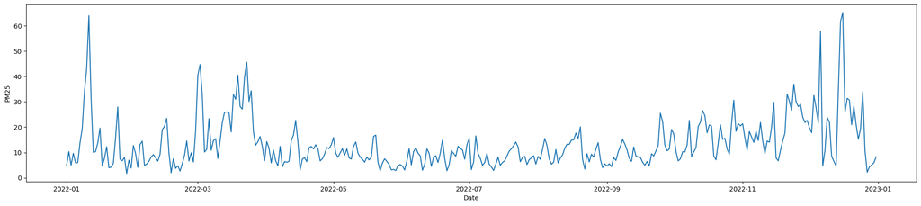

```python
fig, ax = plt.subplots(1,1,figsize=(25,5))
sns.lineplot(x=df.index, y=df['PM25'],ax=ax,data=df)

plt.show()
```

## 2. Feature Engineering

### 2.1 Rolling Windows

```python
stats = ['mean','median','std']
```

Wybrane statystyki do przedstawienia w oknach to średnia, mediana jako alternatywa dla średniej oraz odchylenie standardowe, które może informować o tym gdzie wystepują duże wahania amplitudy sygnału.

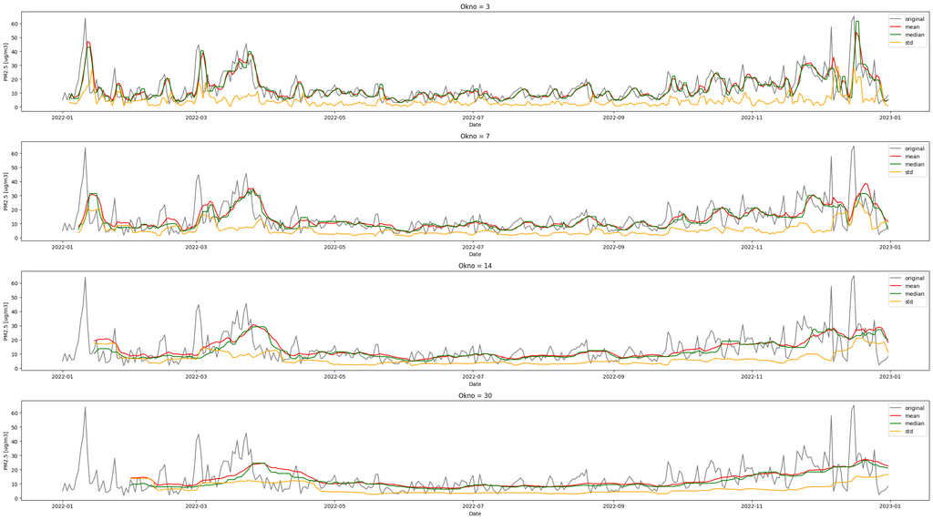

```python
colors = ['red','green','orange']
windows = [3, 7, 14, 30]
fig, ax = plt.subplots(len(windows), 1, figsize = [25, 14])
for j, window in enumerate(windows):

    sns.lineplot(data = df, x = df.index, y = 'PM25', ax = ax[j], color = 'grey', label = 'original')
    ax[j].set_title(f'Okno = {window}')
    ax[j].grid()
    # ax[i].set_xlim(np.min(data.index), np.max(data.index))
    ax[j].set_ylabel('PM2.5 [ug/m3]')

    rolling_df = df.rolling(window=window).agg(stats).shift(1)

    for i, stat in enumerate(stats):

        sns.lineplot(data = rolling_df, x = rolling_df.index, y = ('PM25', stat), ax = ax[j], color = colors[i], label = stat)
        ax[j].set_title(f'Okno = {window}')
        ax[j].grid()
        # ax[i].set_xlim(np.min(data.index), np.max(data.index))
        ax[j].set_ylabel('PM2.5 [ug/m3]')

plt.tight_layout()
plt.show()
```

*Wnioski:*

- Mediana dla wszystkich wykresów wydaje się być gorszą statystyką do wyświetlania niż średnia, bo w sygnałach mediany występują schodki, średnia jest bardziej wygładzona.
- Średnia i mediana dla okna 3 wyglądają jak wykres lagu z lekkim wyglądzeniem sygnału, odchylenie standardowe wydaje się dobrze pokazywać zaburzenia amplitudy sygnału.
- Dla okien 14 i 30 wszystki pomiary mocno wygładzają sygnał. Przy oknie 30 średnia i mediana działają trochę jak trend. Dodatkowo te okna powodują większe braki na początku zbioru danych.

Po analizie wykresów do zbioru dołączone zostaną okna 3 i 7 dla średniej oraz 3 dla odchylenia standardowego.

```python
df['PM_25_rolling_mean_3'] = df.rolling(window=3).agg('mean').shift(1)['PM25']
df['PM_25_rolling_mean_7'] = df.rolling(window=7).agg('mean').shift(1)['PM25']
df['PM_25_rolling_std_3'] = df.rolling(window=3).agg('std').shift(1)['PM25']
```

### 2.2 Expanding Windows

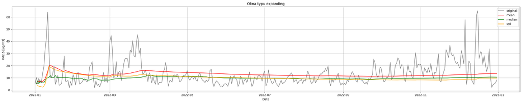

```python
expanding_df = df.expanding().agg(stats)
colors = ['red','green','orange']

fig, ax = plt.subplots(1, 1, figsize = [25, 5])

sns.lineplot(data = df, x = df.index, y = 'PM25', ax = ax, color = 'grey', label = 'original')
ax.set_title(f'Okna typu expanding')
ax.grid()
# ax[i].set_xlim(np.min(data.index), np.max(data.index))
ax.set_ylabel('PM2.5 [ug/m3]')

rolling_df = df['PM25'].expanding().agg(stats).shift(1)

for i, stat in enumerate(stats):

    sns.lineplot(data = rolling_df, x = rolling_df.index, y = stat, ax = ax, color = colors[i], label = stat)


plt.tight_layout()
plt.show()
```

```python
df['PM_25_expanding_mean'] = df['PM25'].expanding().agg('mean').shift(1)
```

### 2.3 Okna czasowe zagnieżdżone

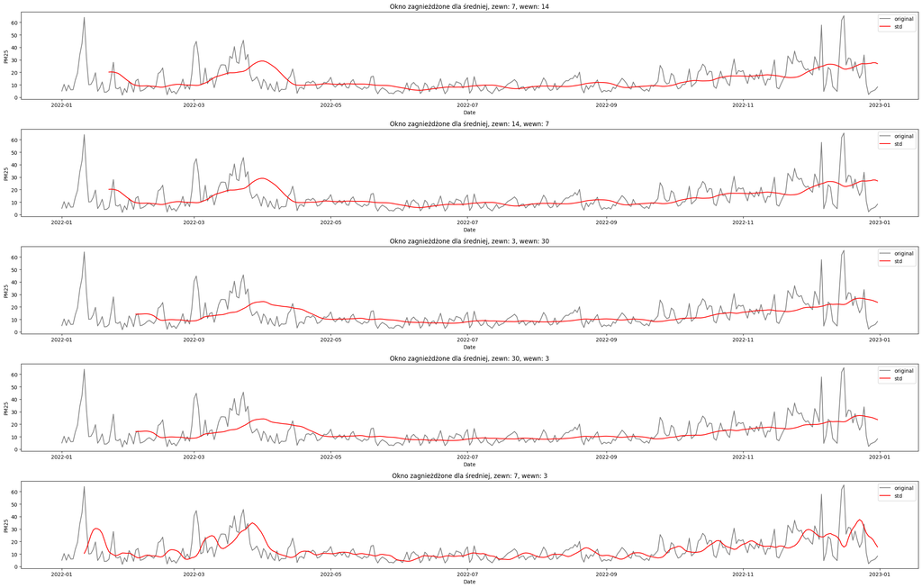

```python
nested_windows = [(7, 14), (14, 7), (3, 30), (30,3),(7,3)]

fig, ax = plt.subplots(len(nested_windows), 1, figsize = [25, 16])

i = 0
for outer_window, inner_window in nested_windows:

    sns.lineplot(data = df, x = df.index, y = 'PM25', ax = ax[i], color = 'grey', label = 'original')

    outer_stats = df['PM25'].rolling(window=outer_window).agg('mean').shift(1)
    nested_df = outer_stats.rolling(window=inner_window).agg('mean').shift(1)

    sns.lineplot(data = nested_df, ax = ax[i], color = 'red', label = stat)
    ax[i].set_title(f'Okno zagnieżdżone dla średniej, zewn: {outer_window}, wewn: {inner_window}')

    i += 1

plt.tight_layout()
plt.show()
```

Okna zagnieżdżone o różnych parametrach dla średniej powodują bardziej przesunięte i wygładzone sygnały. Z tego powodu nie zostaną dodane do danych.

### 2.4 Wartości opóznione bazując na ACF

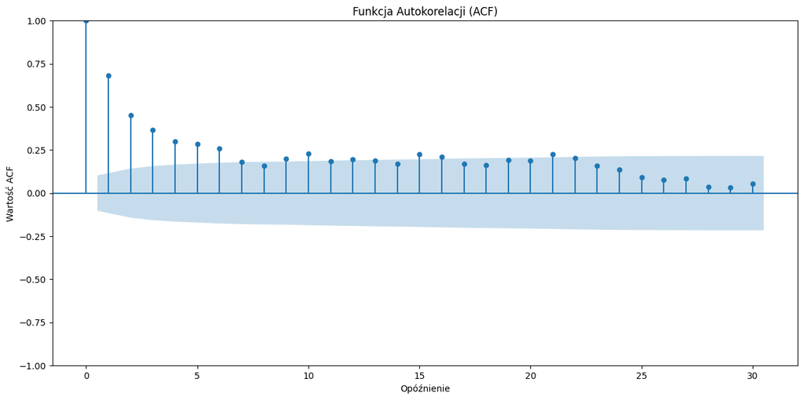

```python
fig,ax = plt.subplots(1,1, figsize = (15,7))

plot_acf(df['PM25'], lags=30, ax=ax)
plt.title("Funkcja Autokorelacji (ACF)")
plt.xlabel("Opóźnienie")
plt.ylabel("Wartość ACF")
```

Na wykresie autokorelacji widoczne są lokalne maksima dla opóźnień 10, 15 i 21, jednak wartość korelacji wychodzi niewiele poza granicę istotności statystycznej. Z tego powodu lepiej wybrać lag=1, dla kótrego korelacja z sygnałem jest najwyższa (nie licząc zerowego opóźnienia).

```python
df['PM25_lag_1'] = df['PM25'].shift(1)
```

### 2.5 Wartości wynikające z daty

```python
df["day_of_week"] = df.index.dayofweek
df["month"] = df.index.month
df["day_of_year"] = df.index.dayofyear
df['is_weekend'] = df['day_of_week'].apply(lambda day: 1 if day > 4 else 0)
```

[output not shown]

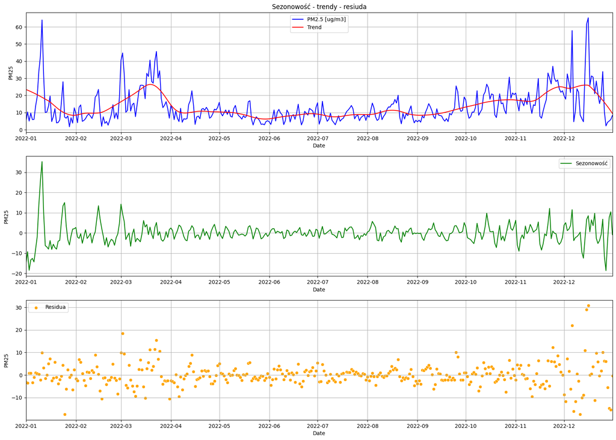

```python
result = STL(df['PM25'], period = 14, seasonal = 5).fit()
df['Trend'], df['Seasonal'], df['Resid'] = result.trend, result.seasonal, result.resid

fig, axes = plt.subplots(3, 1, figsize = [20, 14])
sns.lineplot(x = df.index,  y = df['PM25'], ax = axes[0], color = 'blue', label = 'PM2.5 [ug/m3]')
sns.lineplot(x = df.index,  y = df['Trend'], ax = axes[0], color = 'red', label = 'Trend')

axes[0].set_ylabel('PM25')
axes[0].grid()
axes[0].set_title('Sezonowość - trendy - resiuda')
axes[0].set_xlim(np.min(df.index), np.max(df.index))

sns.lineplot(x = df.index,  y = df['Seasonal'], ax = axes[1], color = 'green', label = 'Sezonowość')
axes[1].set_ylabel('PM25')
axes[1].grid()
axes[1].set_xlim(np.min(df.index), np.max(df.index))

sns.scatterplot(x = df.index,  y = df['Resid'], ax = axes[2], color = 'orange', label = 'Residua')
axes[2].set_ylabel('PM25')
axes[2].grid()
axes[2].set_xlim(np.min(df.index), np.max(df.index))
```

Ciężko o jeden wyraźny trend sezonowy w prezentowanych danych. Przypuszczalnie roczny trend byłby widoczny najlepiej, jednak dane dostępne są jedynie z jednego roku. Po testach różnych wartości period oraz seasonal, wydaje się, że względnie dobre rezultaty dają parametry:

period = 14

seasonal = 5  
Widoczne jest na wykresie residuów, że najlepiej STL poradził sobie w okresie letnim, gdzie oscylują one najbliżej wartości 0.

### Zbiór danych uzyskanych w ramach feature engineeringu:

```python
df
```

| Date | PM25 | PM_25_rolling_mean_3 | PM_25_rolling_mean_7 | PM_25_rolling_std_3 | PM_25_expanding_mean | PM25_lag_1 | day_of_week | month | day_of_year | is_weekend | Trend | Seasonal | Resid |
| --- | --- | --- | --- | --- | --- | --- | --- | --- | --- | --- | --- | --- | --- |
| 2022-01-01 | 4.934921 | NaN | NaN | NaN | NaN | NaN | 5 | 1 | 1 | 1 | 23.462780 | -15.312148 | -3.215711 |
| 2022-01-02 | 10.341562 | NaN | NaN | NaN | 4.934921 | 4.934921 | 6 | 1 | 2 | 1 | 23.068670 | -9.295525 | -3.431583 |
| 2022-01-03 | 5.007348 | NaN | NaN | NaN | 7.638241 | 10.341562 | 0 | 1 | 3 | 0 | 22.660735 | -18.458270 | 0.804884 |
| 2022-01-04 | 9.688094 | 6.761277 | NaN | 3.100829 | 6.761277 | 5.007348 | 1 | 1 | 4 | 0 | 22.238719 | -13.332477 | 0.781852 |
| 2022-01-05 | 5.914476 | 8.345668 | NaN | 2.909474 | 7.492981 | 9.688094 | 2 | 1 | 5 | 0 | 21.802361 | -12.600969 | -3.286916 |
| ... | ... | ... | ... | ... | ... | ... | ... | ... | ... | ... | ... | ... | ... |
| 2022-12-27 | 2.195314 | 21.263458 | 21.348769 | 11.735045 | 13.502847 | 10.631678 | 1 | 12 | 361 | 0 | 14.730553 | -18.625751 | 6.090513 |
| 2022-12-28 | 4.317930 | 15.560667 | 18.668857 | 16.395281 | 13.471524 | 2.195314 | 2 | 12 | 362 | 0 | 13.489510 | -3.689109 | -5.482470 |
| 2022-12-29 | 5.061757 | 5.714974 | 15.232136 | 4.388264 | 13.446238 | 4.317930 | 3 | 12 | 363 | 0 | 12.205193 | 7.670118 | -14.813554 |
| 2022-12-30 | 5.950761 | 3.858334 | 12.943590 | 1.487463 | 13.423140 | 5.061757 | 4 | 12 | 364 | 0 | 10.876037 | 10.437035 | -15.362311 |
| 2022-12-31 | 8.273009 | 5.110149 | 11.616591 | 0.817490 | 13.402611 | 5.950761 | 5 | 12 | 365 | 1 | 9.503466 | -0.892377 | -0.338080 |

365 rows × 13 columns

## 3. Przedstaw uzyskany zbiór cech na w przejrzysty sposób na wykresach i opisz co można na ich podstawie zinterpretować.

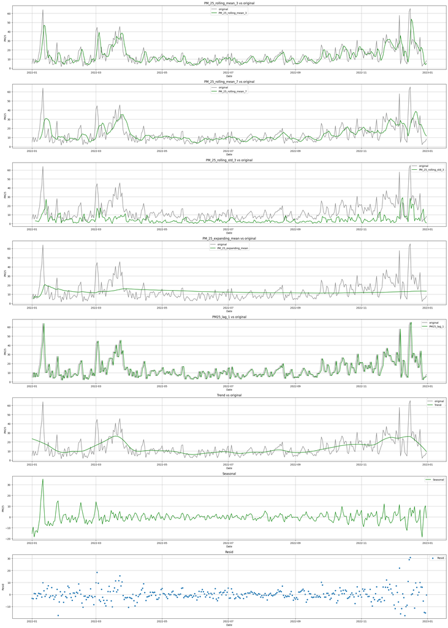

```python
col_list = ['PM_25_rolling_mean_3', 'PM_25_rolling_mean_7',
       'PM_25_rolling_std_3', 'PM_25_expanding_mean', 'PM25_lag_1', 'Trend',
       'Seasonal', 'Resid']

fig, ax = plt.subplots(len(col_list), 1, figsize = [25, 35])

for i, col in enumerate(col_list):
       if(col not in ['Seasonal', 'Resid']):
              sns.lineplot(data = df, x = df.index, y = 'PM25', ax = ax[i], color = 'grey', label = 'original')
              ax[i].set_title(col + ' vs original')
       else:
               ax[i].set_title(col)

       if col == 'Resid':
              sns.scatterplot(x = df.index,y=df[col], ax = ax[i], label = col)
       else:
              sns.lineplot(x = df.index,  y = df[col], ax = ax[i], color = 'green', label = col)
              ax[i].set_ylabel('PM25')


       ax[i].grid()

plt.tight_layout()
plt.show()
```

Interpetacje dodawanych cech zostały umieszczone bezpośrednio pod odpowiadającym im kodem.